# MPP-E1180 Lecture 9: Statistical Modeling with R

## Diagnose heteroscedasticity

Use `plot` on a model object to run visual diagnostics.

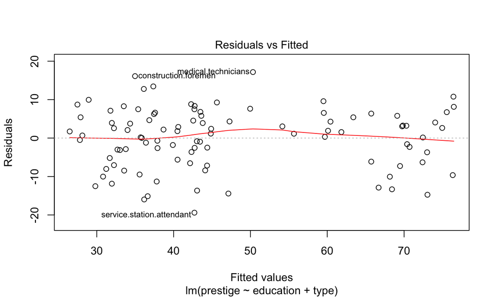

```r
plot(M2, which = 1)
```

## Diagnose non-normality of errors

`plot` to see if a model's errors are normally distributed.

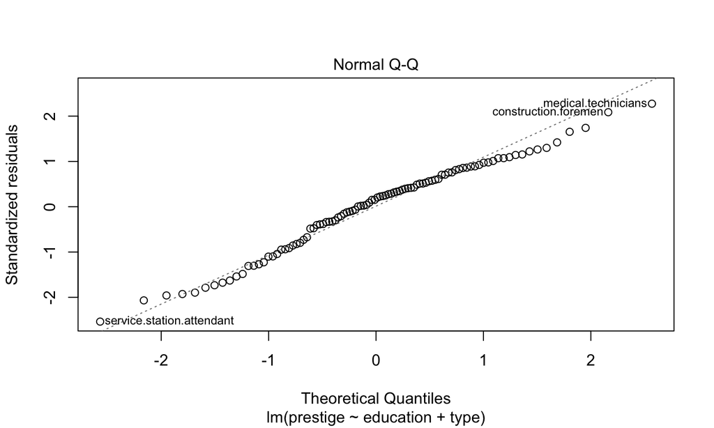

```r
plot(M2, which = 2)
```

## Example of logistic regression with `glm`

Example from [UCLA IDRE](http://www.ats.ucla.edu/stat/r/dae/logit.htm).

Simulated data of admission to grad school.

```r
# Load data
URL <- 'http://www.ats.ucla.edu/stat/data/binary.csv'
Admission <- read.csv(URL)
```

## Example of logistic regression with `glm`

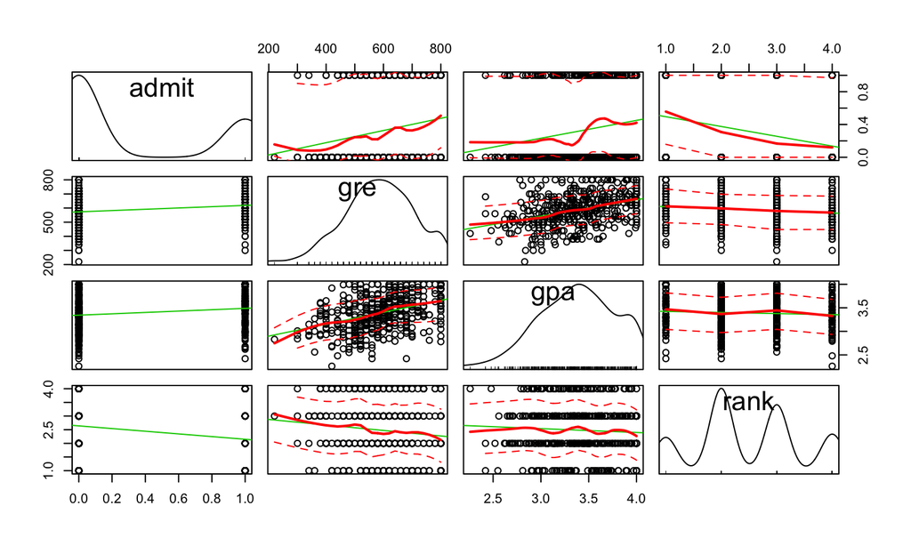

```r
car::scatterplotMatrix(Admission)
```

## Contingency table for school rank and admission

```r
admit_table <- xtabs(~admit + rank, data = Admission)
admit_table
```

```
##      rank
## admit  1  2  3  4
##     0 28 97 93 55
##     1 33 54 28 12
```

## Row and column proportions

```r
# Row proportions
prop.table(admit_table, margin = 1)
```

```
##      rank
## admit          1          2          3          4
##     0 0.10256410 0.35531136 0.34065934 0.20146520
##     1 0.25984252 0.42519685 0.22047244 0.09448819
```

```r
# Column proportions
prop.table(admit_table, margin = 2)
```

```
##      rank
## admit         1         2         3         4
##     0 0.4590164 0.6423841 0.7685950 0.8208955
##     1 0.5409836 0.3576159 0.2314050 0.1791045
```

## Summary of contingency table for school rank and admission

```r
summary(admit_table)
```

```
## Call: xtabs(formula = ~admit + rank, data = Admission)
## Number of cases in table: 400
## Number of factors: 2
## Test for independence of all factors:
##  Chisq = 25.242, df = 3, p-value = 1.374e-05
```

## Example of logistic regression with `glm`

```r
Logit1 <- glm(admit ~ gre + gpa + as.factor(rank),
              data = Admission, family = 'binomial')
```

Note: Link function is assumed to be logit if `family = 'binomial'`.

## Example of logistic regression with `glm`

```r
confint(Logit1)
```

```
##                          2.5 %       97.5 %
## (Intercept)      -6.2716202334 -1.792547080
## gre               0.0001375921  0.004435874
## gpa               0.1602959439  1.464142727
## as.factor(rank)2 -1.3008888002 -0.056745722
## as.factor(rank)3 -2.0276713127 -0.670372346
## as.factor(rank)4 -2.4000265384 -0.753542605
```

## Interpreting logistic regression results

\(\beta\)'s in logistic regression are interpretable as **log odds**. These are weird.

If we exponentiate log odds we get **odds ratios**.

```r
exp(cbind(OddsRatio = coef(Logit1), confint(Logit1)))
```

```
##                  OddsRatio       2.5 %    97.5 %
## (Intercept)      0.0185001 0.001889165 0.1665354
## gre              1.0022670 1.000137602 1.0044457
## gpa              2.2345448 1.173858216 4.3238349
## as.factor(rank)2 0.5089310 0.272289674 0.9448343
## as.factor(rank)3 0.2617923 0.131641717 0.5115181
## as.factor(rank)4 0.2119375 0.090715546 0.4706961
```

These are **also weird**.

## Interpreting logistic regression results

What we really want are **predicted probabilities**

**First** create a data frame of fitted values:

```r
fitted <- with(Admission,
               data.frame(gre = mean(gre),
                          gpa = mean(gpa),
                          rank = factor(1:4)))
fitted
```

```
##     gre    gpa rank
## 1 587.7 3.3899    1
## 2 587.7 3.3899    2
## 3 587.7 3.3899    3
## 4 587.7 3.3899    4
```

## Interpreting logistic regression results

**Second** predict probability point estimates for each fitted value.

```r
fitted$predicted <- predict(Logit1, newdata = fitted,
                            type = 'response')

fitted
```

```
##     gre    gpa rank predicted
## 1 587.7 3.3899    1 0.5166016
## 2 587.7 3.3899    2 0.3522846
## 3 587.7 3.3899    3 0.2186120
## 4 587.7 3.3899    4 0.1846684
```

## Showing results from regression models with simulations

King, Tomz, and Wittenberg (2001) argue that **post-estimation simulations** can be used to effectively communicate **results from regression models**.

## Steps

1. Estimate our parameters' point estimates for \(\hat{\beta}_{1\ldots k}\).
2. Draw \(n\) values of the point estimates from multivariate normal distributions with means \(\bar{\beta}_{1\ldots k}\) and variances specified by the parameters' estimated co-variance.
3. Use the simulated values to calculate quantities of interest (e.g. predicted probabilities).
4. Plot the simulated distribution using **visual weighting**.

## Notes

Post-estimation simulations allow us to effectively communicate our estimates and the **uncertainty around them**.

This method is broadly similar to a fully Bayesian approach with Markov-Chain Monte Carlo or bootstrapping. Just differ on **how the parameters are drawn**.

## Implementation

1. Find the coefficient estimates from an estimated model with `coef`.
2. Find the co-variance matrix with `vcov`.
3. Draw point estimates from the multivariate normal distribution with `mvrnorm`.
4. Calculate the quantity of interest with the draws + fitted values using and plot the results.

## Simulations: estimate model

First estimate your model as normal and create fitted values:

```r
library(car) # Contains data
library(dplyr) # Piping function
M_prest <- lm(prestige ~ education + type,
         data = Prestige)

# Find a range of education values
range(Prestige$education)
```

```
## [1]  6.38 15.97
```

```r
edu_range <- 6:16
```

## Simulations: extract estimates

Extract point estimates (coefficients) and co-variance matrix:

```r
mp_coef <- matrix(coef(M_prest))
mp_vcov <- vcov(M_prest)
```

Now draw 1,000 simulations of your point estimates:

```r
library(MASS) # contains the mvrnorm function
drawn <- mvrnorm(n = 1000, mu = mp_coef, Sigma = mp_vcov) %>%
            data.frame
head(drawn)[1:3, ]
```

```
##   X.Intercept. education typeprof    typewc
## 1    -1.963977  4.378190 8.449935 -2.748082
## 2     1.867675  4.157990 9.968692 -5.090633
## 3    -4.213891  4.840518 4.676530 -6.004704
```

## Simulations: merge in fitted values

Now we can add in our fitted values to the simulation data frame:

```r
drawn_sim <- merge(drawn, edu_range)

# Rename the fitted value variable
drawn_sim <- dplyr::rename(drawn_sim, fitted_edu = y)

nrow(drawn)
```

```
## [1] 1000
```

```r
nrow(drawn_sim)
```

```
## [1] 11000
```

## Simulations: calculate quantity of interest

```r
names(drawn_sim)
```

```
## [1] "X.Intercept." "education"    "typeprof"     "typewc"
## [5] "fitted_edu"
```

```r
drawn_sim$sim_wc <- drawn_sim[, 1] + drawn_sim[, 2] * drawn_sim[, 5] +
                        drawn_sim[, 3]
```

## Simulations: plot points

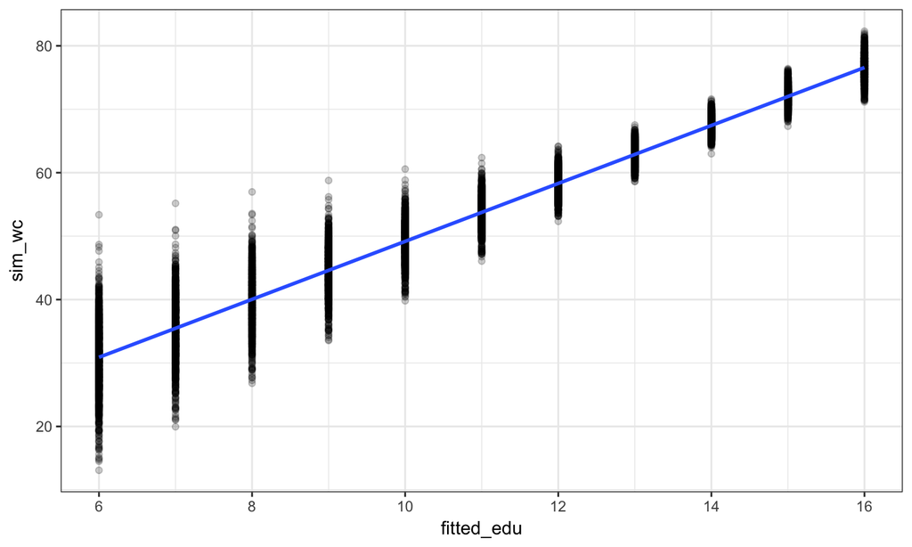

```r
ggplot(drawn_sim, aes(fitted_edu, sim_wc)) +
        geom_point(alpha = 0.2) + stat_smooth(se = FALSE) +
        theme_bw()
```

## Simulations: find 95% central interval ribbons

```r
# Find 95% central interval and median at each fitted value of edu
central <- drawn_sim %>% group_by(fitted_edu) %>%
            summarise(median_sim = median(sim_wc),
                      lower_95 = quantile(sim_wc, probs = 0.025),
                      upper_95 = quantile(sim_wc, probs = 0.975)
            )
```

## Simulations: plot 95% central interval

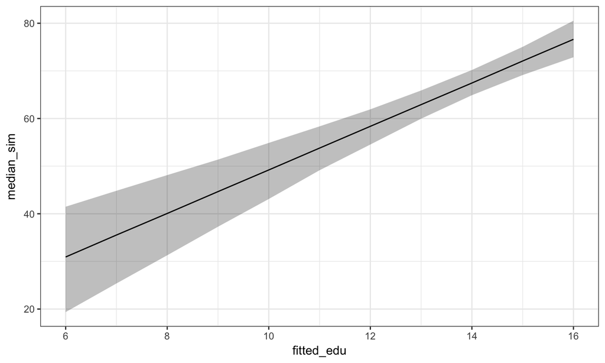

```r
ggplot(central, aes(fitted_edu, median_sim)) +
    geom_ribbon(aes(ymin = lower_95, ymax = upper_95), alpha = 0.3) +
    geom_line() + theme_bw()
```

## Easier Implementation

The [Zelig](http://gking.harvard.edu/zelig) package streamlines the simulation process.

Note: There appears to be a bug in Zelig version 5.0-13 when dealing with factor-level explanatory variables. So, use version 5.0-11:

```r
devtools::install_version('Zelig', version = '5.0-11')
```

## Zelig (1)

First estimate your regression model using `zelig`.

```r
library(Zelig)

# Have to explicitly declare rank as factor
Admission$rank <- as.factor(Admission$rank)

Z1 <- zelig(admit ~ gre + gpa + rank, cite = FALSE,
              data = Admission, model = 'logit')
```

## Zelig (2)

Then set the fitted values with `setx`.

```r
setZ1 <- setx(Z1, gre = 220:800)
```

And run the simulations (1,000 by default) with `sim`.

```r
simZ1 <- sim(Z1, x = setZ1)
```

## Zelig (3)

Plot:

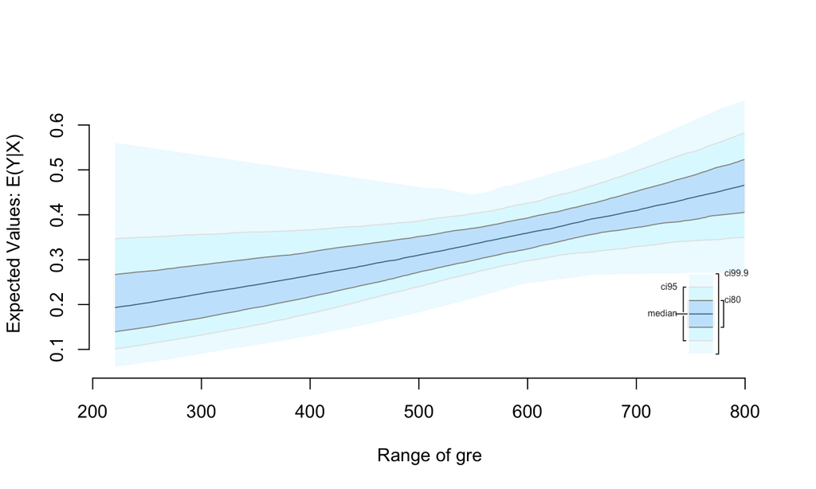

```r
ci.plot(simZ1)
```

## Seminar: modeling

Begin working on the statistical models for **your project**.

and/or

**Out of Lecture Challenge**: Estimate a normal regression model and **plot predicted values** across a range of fitted values. Bonus: do so with a measure of uncertainty.

## References

King, Gary, Micheal Tomz, and Jason Wittenberg. 2001. “Making the Most of Statistical Analyses: Improving Interpretation and Presentation.” *American Journal of Political Science* 22 (4): 341–255.